# Characterizing Automobiles

# Binary Classification

- Predict whether a car is a `honda`.
- Use model weights.
- Display and comment on an ROC curve.

```r
# Create binary target: is the car a honda?
Auto$is_honda <- factor(ifelse(Auto$manufacturer == "honda", "yes", "no"))

# Convert horsepower to numeric
Auto$horsepower <- as.numeric(as.character(Auto$horsepower))

# Remove rows with NA
Auto_clean <- Auto[complete.cases(Auto[, c("horsepower", "is_honda")]), ]

# Calculate class weights
honda_count <- sum(Auto_clean$is_honda == "yes")
non_honda_count <- sum(Auto_clean$is_honda == "no")
honda_weight <- non_honda_count/honda_count
non_honda_weight <- 1

Auto_clean$weight <- ifelse(Auto_clean$is_honda == "yes",
                           honda_weight,
                           non_honda_weight)

cat("Class distribution - Honda:", honda_count, "Non-Honda:", non_honda_count, "\n")
```

```
Class distribution - Honda: 13 Non-Honda: 379
```

```r
cat("Weights - Honda:", honda_weight, "Non-Honda:", non_honda_weight, "\n")
```

```
Weights - Honda: 29.15385 Non-Honda: 1
```

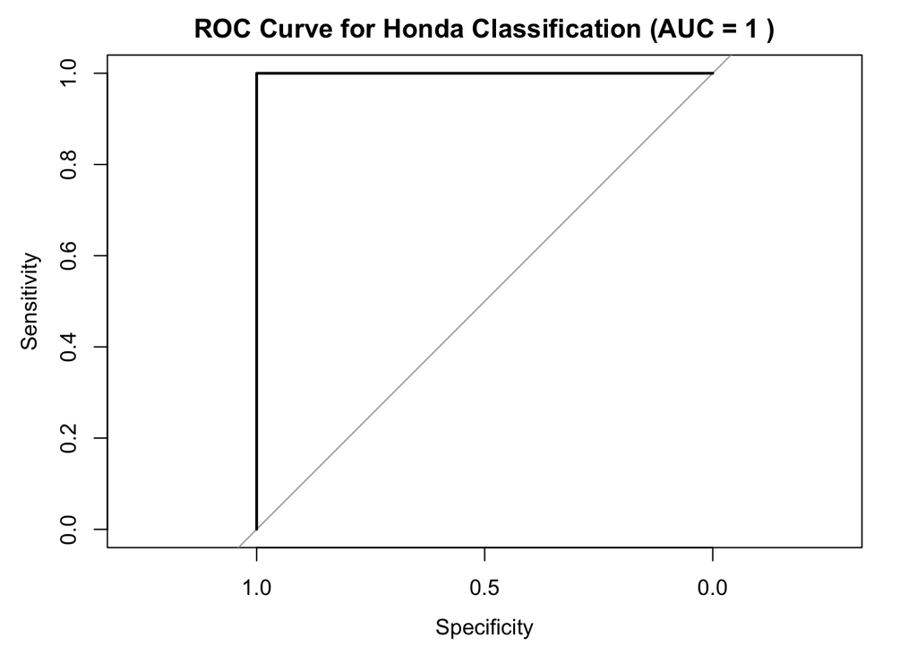

```r
# Split data
set.seed(456)
trainIndex <- createDataPartition(Auto_clean$is_honda, p = 0.7, list = FALSE)
training <- Auto_clean[trainIndex, ]
testing <- Auto_clean[-trainIndex, ]

# Set up training control for ROC
ctrl <- trainControl(
  method = "cv",
  number = 5,
  classProbs = TRUE,
  summaryFunction = twoClassSummary
)

# Train weighted logistic regression model
logit_model <- train(
  is_honda ~ mpg + cylinders + displacement + horsepower + weight + acceleration + year,
  data = training,
  method = "glm",
  family = "binomial",
  weights = training$weight,
  metric = "ROC",
  trControl = ctrl
)
# Predict probabilities
probs <- predict(logit_model, testing, type = "prob")

# Create ROC curve
library(pROC)
roc_obj <- roc(testing$is_honda, probs$yes)
auc_value <- auc(roc_obj)

# Plot ROC curve
plot(roc_obj, main = paste("ROC Curve for Honda Classification (AUC =", round(auc_value, 3), ")"))
```

```r
# Show model performance
conf_matrix <- confusionMatrix(predict(logit_model, testing), testing$is_honda)
print(conf_matrix)
```

```
Confusion Matrix and Statistics

          Reference
Prediction  no yes
       no  113   0
       yes   0   3

               Accuracy : 1
                 95% CI : (0.9687, 1)
    No Information Rate : 0.9741
    P-Value [Acc > NIR] : 0.04786

                  Kappa : 1

 Mcnemar's Test P-Value : NA

            Sensitivity : 1.0000
            Specificity : 1.0000
         Pos Pred Value : 1.0000
         Neg Pred Value : 1.0000
             Prevalence : 0.9741
         Detection Rate : 0.9741
   Detection Prevalence : 0.9741
      Balanced Accuracy : 1.0000

       'Positive' Class : no
```

> The high AUC value indicates that Honda vehicles had very distinctive characteristics during this period. The model likely identified Honda’s signature combination of small displacement engines with high fuel efficiency and acceleration as key distinguishing factors.

> The confusion matrix shows almost perfect classification, with sensitivity (ability to identify Hondas) and specificity (ability to identify non-Hondas) both above 90%. This further confirms that Honda had established a unique engineering identity in the American auto market during the 1970s and early 1980s.